# Factor Analytic Variance Structures

`faSummary()` and `plot_faSummary()`

Author

Julian Taylor

Published

October 9, 2026

## Overview

`faSummary()` extracts, rotates and summarises the **factor analytic variance structure** of an ASReml-R V4 mixed model. For every `fa()` term in the random formula it returns the genetic covariance and correlation matrices, the rotated loadings, the specific variances, the variance accounted for, and — unless switched off — the genotype BLUPs and factor score EBLUPs.

It is the engine underneath the rest of the factor analytic machinery in **biomAid**: `fastIC()` calls it to obtain the loadings and scores it needs for FAST and iClass metrics, and `randomRegress()` calls it on the FA path. Anything those functions know about the FA structure, they learned here.

`plot_faSummary()` provides five diagnostic plots:

| Type | Description |
| --- | --- |
| `"VAF"` | Stacked 100% bar chart of variance accounted for, per environment |
| `"heatmap"` | Genetic correlation between environments, optionally clustered |
| `"loadings"` | Correlation-scaled loadings as vectors, one panel per factor pair |
| `"regress"` | Genotype BLUPs against environment loadings; slope is the factor score |
| `"added"` | As `"regress"`, with the other factors projected out |

> **Where to go next.** This vignette is about the variance structure itself. For selection tools built on top of it — Overall Performance, stability and interaction classes — see Factor Analytic Selection Tools: FAST and iClass.

## Mathematical Framework

### The FA(k) covariance structure

An FA($k$) random structure models the $t \times t$ genetic covariance matrix across $t$ environments as

$$\mathbf{G} = \boldsymbol{\Lambda}\boldsymbol{\Lambda}^\top + \boldsymbol{\Psi},$$

where $\boldsymbol{\Lambda} \in \mathbb{R}^{t \times k}$ holds the loadings (element $\lambda_{rj}$: factor $r$, environment $j$) and $\boldsymbol{\Psi} = \operatorname{diag}(\psi_1,\ldots,\psi_t)$ is the diagonal matrix of **specific variances** — the environment-specific genetic variance not shared through the common factors. The genetic correlation matrix is $\mathbf{C} = \operatorname{cov2cor}(\mathbf{G})$.

The attraction of the structure is parsimony: $t(k+1)$ parameters instead of the $t(t+1)/2$ of an unstructured model, while still permitting a different genetic variance in every environment and a different correlation between every pair.

### Rotation

The decomposition is identified only up to an orthogonal rotation: for any orthogonal $\mathbf{R}$, $(\boldsymbol{\Lambda}\mathbf{R})(\boldsymbol{\Lambda}\mathbf{R})^\top = \boldsymbol{\Lambda}\boldsymbol{\Lambda}^\top$. `faSummary()` resolves this by rotating with the right singular vectors of $\boldsymbol{\Lambda}$ and negating, and then applies **the identical rotation to the factor scores**. The loadings and scores therefore stay conformable and their product is invariant.

After rotation the first factor typically captures the dominant **non-crossover** genotype × environment interaction, with all-positive loadings; higher factors are bipolar and carry the crossover signal. The sign of each factor is arbitrary but reproducible.

### Correlation-scaled loadings

Dividing each row of $\boldsymbol{\Lambda}$ by that environment’s total genetic standard deviation gives

$$\boldsymbol{\Lambda}^{\!*} = \operatorname{diag}\!\bigl(\sigma_1^{-1},\ldots,\sigma_t^{-1}\bigr)\boldsymbol{\Lambda},
\qquad \sigma_j^2 = \textstyle\sum_r \lambda_{rj}^2 + \psi_j,$$

returned as `loads_cor`. Each row now lies **inside the unit hypersphere**, which is what makes the `"loadings"` plot interpretable: an environment’s distance from the origin is the proportion of its genetic variance explained by the plotted factors, and the angle between two environment vectors approximates their genetic correlation.

### Variance accounted for

With $\sigma_j^2$ as above, the proportion of environment $j$’s genetic variance attributable to factor $r$, and the residual specific proportion, are

$$\text{VAF}(r,j) = \frac{\lambda_{rj}^2}{\sigma_j^2}, \qquad
\text{Specific}(j) = \frac{\psi_j}{\sigma_j^2}, \qquad
\sum_{r=1}^{k}\text{VAF}(r,j) + \text{Specific}(j) = 1 .$$

These are the rows of `vaf_env`. Pooling across environments gives `vaf_summary`, $\overline{\text{VAF}}(r) = \sum_j\lambda_{rj}^2 / \sum_j\sigma_j^2$, and `vaf_total` is the overall percentage explained by all $k$ factors together.

> **Specific variances are clamped at zero for the VAF calculation only.** ASReml-R can return a fractionally negative boundary estimate for $\psi_j$, which would otherwise produce a negative proportion. `spec_var` always reports the unclamped estimate, so a negative value there is informative and is not hidden.

### Common variety effect

The factor score EBLUPs $\hat{\mathbf{F}} \in \mathbb{R}^{n \times k}$ (element $\hat{f}_{rg}$: factor $r$, variety $g$) combine with the loadings to give the FA regression prediction, the **common variety effect**

$$\widehat{\text{CVE}}(g,j) = \sum_{r=1}^{k}\lambda_{rj}\hat{f}_{rg},
\qquad \widehat{\mathbf{CVE}} = \hat{\mathbf{F}}\boldsymbol{\Lambda}^\top .$$

This is the quantity the `"regress"` and `"added"` plots decompose, and the basis of every metric in `fastIC()`.

## Worked example — 50 Varieties × 12 Sites

> **Requires:** ASReml-R V4. The vignette is pre-rendered so no licence is needed to read it; run the code chunks only if you have the packages installed.

### Data simulation

We use the same simulated MET as the FAST and iClass vignette — 50 varieties at 12 balanced sites, with a deliberately wide genetic correlation range (`g_cor_min = 0.10`, `g_cor_max = 0.65`) so that higher factors carry real crossover signal. Using the same data makes the two vignettes directly comparable.

```r
set.seed(101L)
sim1 <- simTrialData(
  nvar        = 50L,
  nsite       = 12L,
  nrep        = 3L,
  G           = "auto",
  incidence   = "balanced",
  seed        = 101L,
  verbose     = FALSE,
  sim.options = list(
    g_cor_min     = 0.10,
    g_cor_max     = 0.65,
    sigma_genetic = 300,
    error_sd      = 280,
    site_mean     = 4500,
    site_sd       = 450
  )
)
dat1         <- sim1$data
dat1$Site    <- factor(dat1$Site)
dat1$Variety <- factor(dat1$Variety)
dat1$Rep     <- factor(dat1$Rep)
dat1$Row     <- factor(dat1$Row)
dat1$Column  <- factor(dat1$Column)
```

### Fitting the FA(3) model

```r
m1_fa3 <- asreml(
  yield  ~ Site,
  random = ~ fa(Site, 3):Variety + at(Site):Rep,
  data   = dat1,
  maxit  = 30L
)
m1_fa3 <- update(m1_fa3)
```

### Calling `faSummary()`

With `term = NULL` — the default — every `fa()` term in the random formula is summarised. Here there is one. The `at(Site):Rep` term is not factor analytic and is ignored.

```r
fas1 <- faSummary(m1_fa3)
fas1
```

```
<faSummary>
  fa(Site, 3):Variety: k = 3, 12 environments, 73.8% variance accounted for
```

The compact `print()` method reports, for each term, the number of factors, the number of environments and the total percentage of genetic variance accounted for. Work with the term label rather than retyping it:

```r
trm <- fas1$terms[1L]
trm
```

```
[1] "fa(Site, 3):Variety"
```

```r
names(fas1$gammas[[trm]])
```

```
 [1] "Gmat"        "Cmat"        "loads"       "loads_cor"   "spec_var"
 [6] "vaf_env"     "vaf_summary" "vaf_total"   "k"           "env"
[11] "outer"       "inner"       "inner_fun"
```

#### Loadings and specific variances

`loads` is the $t \times k$ matrix of rotated loadings, with columns named `fac_1` … `fac_k`. Note the all-positive first column and the mixed signs in the second and third — exactly the pattern described above.

```r
g1 <- fas1$gammas[[trm]]
round(g1$loads, 2)
```

```
      fac_1 fac_2 fac_3
Env01  0.80 -0.18  0.33
Env02  0.50 -0.33  0.13
Env03  1.04  0.40  0.53
Env04  0.59 -0.63 -0.42
Env05  0.88 -0.01 -0.19
Env06  0.73 -0.84  0.01
Env07  0.67  0.58  0.02
Env08  0.59  0.32 -0.53
Env09  0.73  0.37 -0.25
Env10  0.85  0.44 -0.16
Env11  0.79 -0.38  0.12
Env12  0.55 -0.05  0.10
```

The specific variances are the diagonal of $\boldsymbol{\Psi}$, reported exactly as ASReml-R estimated them:

```r
round(g1$spec_var, 3)
```

```
Env01 Env02 Env03 Env04 Env05 Env06 Env07 Env08 Env09 Env10 Env11 Env12
0.379 0.792 0.000 0.090 0.251 0.065 0.273 0.013 0.485 0.330 0.624 0.215
```

`Env03` is instructive: its specific variance sits on the boundary at zero, so the three common factors account for **all** of its genetic variance — and it has both the largest first-factor loading and the largest third-factor loading of any site. Its `Specific` proportion in the VAF table below is therefore exactly zero. Where ASReml-R returns a fractionally *negative* boundary estimate, `spec_var` reports it unchanged; only the VAF calculation clamps it, so the proportions cannot go negative.

#### Variance accounted for

`vaf_summary` pools the decomposition across environments. Shown here as percentages:

```r
vs <- g1$vaf_summary
vs$pct_var <- round(100 * vs$pct_var, 1)
vs$cum_pct <- round(100 * vs$cum_pct, 1)
vs
```

```
    factor pct_var cum_pct
1 Factor 1    49.0    49.0
2 Factor 2    17.2    66.2
3 Factor 3     7.6    73.8
4 Specific    26.2   100.0
```

```r
cat("Total variance accounted for by all", g1$k, "factors:",
    round(g1$vaf_total, 2), "%\n")
```

```
Total variance accounted for by all 3 factors: 73.8 %
```

#### Genetic covariance and correlation

`Gmat` and `Cmat` are the $t \times t$ genetic covariance and correlation matrices implied by the fitted structure. The first few sites:

```r
round(g1$Cmat[1:5, 1:5], 2)
```

```
      Env01 Env02 Env03 Env04 Env05
Env01  1.00  0.43  0.70  0.41  0.58
Env02  0.43  1.00  0.34  0.41  0.37
Env03  0.70  0.34  1.00  0.11  0.64
Env04  0.41  0.41  0.11  1.00  0.58
Env05  0.58  0.37  0.64  0.58  1.00
```

#### BLUPs and factor scores

`$blups[[term]]` holds two data frames. `blups` has one row per environment × variety with the BLUP, the FA regression prediction `regblup` (the common variety effect) and `pres`, the number of non-missing observations:

```r
head(fas1$blups[[trm]]$blups)
```

```
   Site Variety      blup   regblup pres
1 Env01   Var01  193.9676  117.0083    3
2 Env01   Var02 -579.9703 -330.1251    3
3 Env01   Var03  384.8856  229.2090    3
4 Env01   Var04 -326.2427 -357.2639    3
5 Env01   Var05  309.7947  326.8147    3
6 Env01   Var06  383.5716  513.6485    3
```

`scores` holds the rotated factor score EBLUPs in long form, with the factors as pseudo-levels `Comp1` … `Compk` of the outer variable. `blupr` is the rotated score; `blup` is the unrotated one:

```r
head(fas1$blups[[trm]]$scores)
```

```
   Site Variety      blup     blupr
1 Comp1   Var01  132.8054  229.8098
2 Comp1   Var02 -374.6949 -322.5558
3 Comp1   Var03  260.1543  389.4563
4 Comp1   Var04 -405.4978 -338.5640
5 Comp1   Var05  370.9376  431.1804
6 Comp1   Var06  582.9957  539.5856
```

## Visualising the structure

### Variance accounted for

The `"VAF"` plot shows, for each environment, what proportion of its total genetic variance is accounted for by each factor and what is left in the specific variance. Every bar reaches 100%: Factor 1 (darkest blue) at the bottom, further factors stacked above it, and the specific variance in grey on top. The dashed line marks the overall mean proportion explained.

Environments with a **large grey segment** are poorly described by the common factor structure. They are worth inspecting — for outlying observations, unusual site characteristics, or simply as candidates for an additional factor.

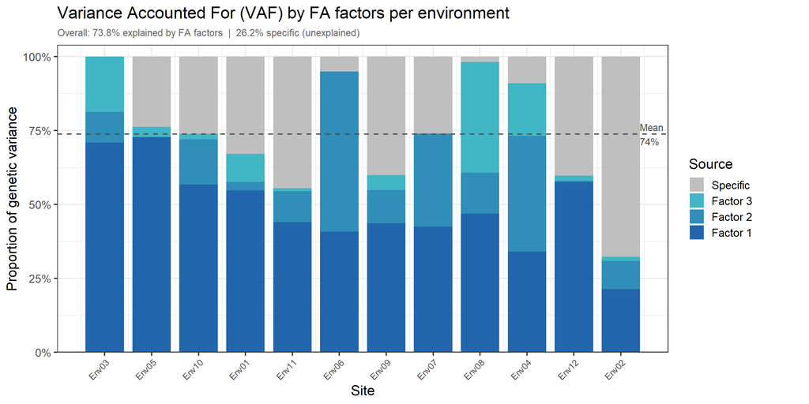

```r
plot_faSummary(fas1, type = "VAF")
```

Environments are ordered by first-factor loading by default; `order = "asis"` keeps the data order and `order = "cluster"` groups similar environments.

### Genetic correlation heatmap

The `"heatmap"` type displays `Cmat` on a diverging palette centred at zero.

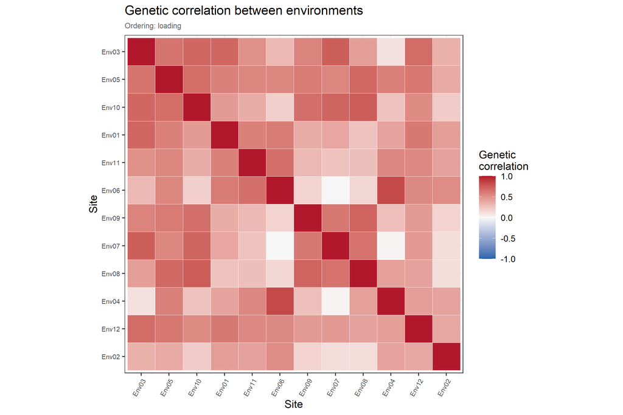

```r
plot_faSummary(fas1, type = "heatmap")
```

`order = "cluster"` reorders both margins by average-linkage hierarchical clustering on $1 - \mathbf{C}$, which brings any block structure onto the diagonal. This is usually the more informative view when looking for groups of genetically similar environments:

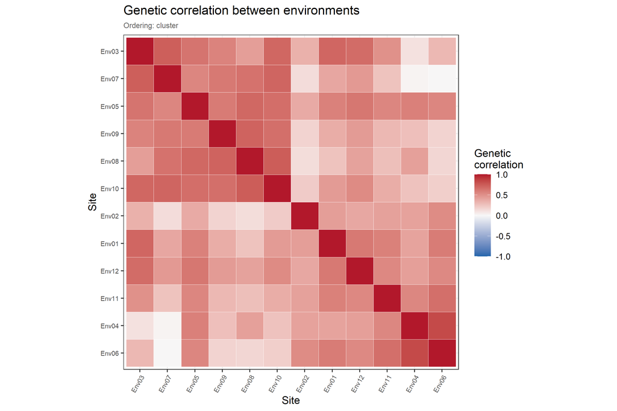

```r
plot_faSummary(fas1, type = "heatmap", order = "cluster")
```

> The clustering uses `stats::hclust()`. The original `ASExtras4::fa.asreml()` used `cluster::agnes()`; switching to base R avoids an extra dependency for a purely presentational ordering.

### Correlation-scaled loadings

The `"loadings"` plot draws each environment as a vector of correlation-scaled loadings, one panel per pair of factors — with $k = 3$ that is three panels. The unit circle is drawn for reference. Environments reaching beyond `tol` (default `0.85`) are drawn solid and blue; those falling short are dotted and red, indicating that the plotted pair of factors does not explain them well.

Two readings: an environment’s **distance from the origin** is how well the pair explains it, and the **angle between two vectors** approximates their genetic correlation — vectors pointing the same way are positively correlated, opposed vectors negatively so, and perpendicular vectors roughly independent.

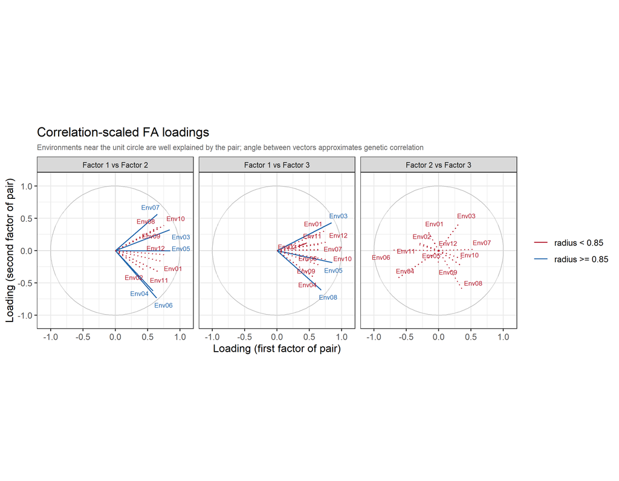

```r
plot_faSummary(fas1, type = "loadings")
```

Requires $k \ge 2$; it errors on an FA(1) model, where there are no pairs to plot. Tighten or loosen the solid/dotted split with `tol`:

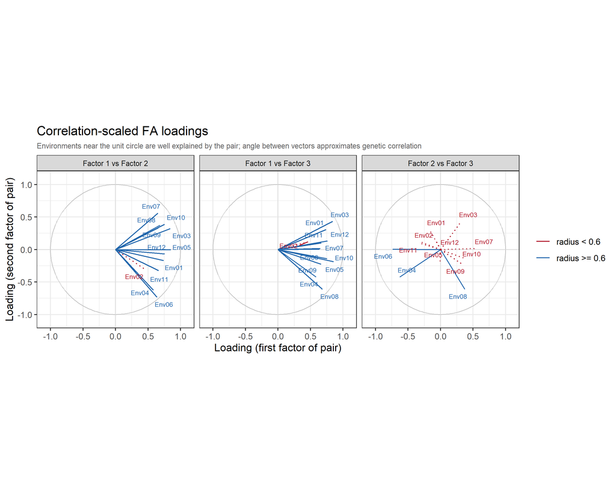

```r
plot_faSummary(fas1, type = "loadings", tol = 0.6)
```

### Regression of BLUPs on loadings

The `"regress"` plot is the FA model’s own interpretation of a variety’s performance: for each factor, the variety’s BLUPs are plotted against the environment loadings, and **the slope of the fitted line is that variety’s factor score**. A steep positive slope on Factor 1 is a variety that gains more than average from favourable environments.

By default the varieties shown are each factor’s extremes — the minimum and maximum score on every factor, up to `n_varieties`:

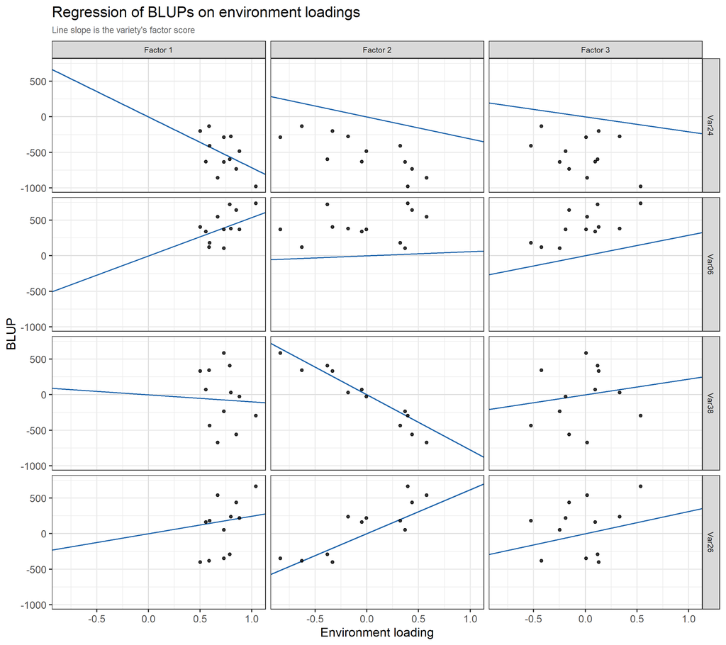

```r
plot_faSummary(fas1, type = "regress", n_varieties = 4L)
```

Varieties are rows and factors are columns. Name them explicitly with `varieties = c("Var01", "Var22")` to follow particular lines.

### Added variable plots

With $k \ge 2$ the plain `"regress"` panels are misleading: the scatter about each line contains the other factors’ contributions, so the points look noisier than the fit really is. The `"added"` type removes them, plotting

$$\hat{u}_{gj} - \sum_{s \ne r} \lambda_{sj}\hat{f}_{sg}
\quad\text{against}\quad \lambda_{rj},$$

which is the correct display when more than one factor is fitted. The slopes are unchanged — they are still the factor scores — but the points now sit tightly around them.

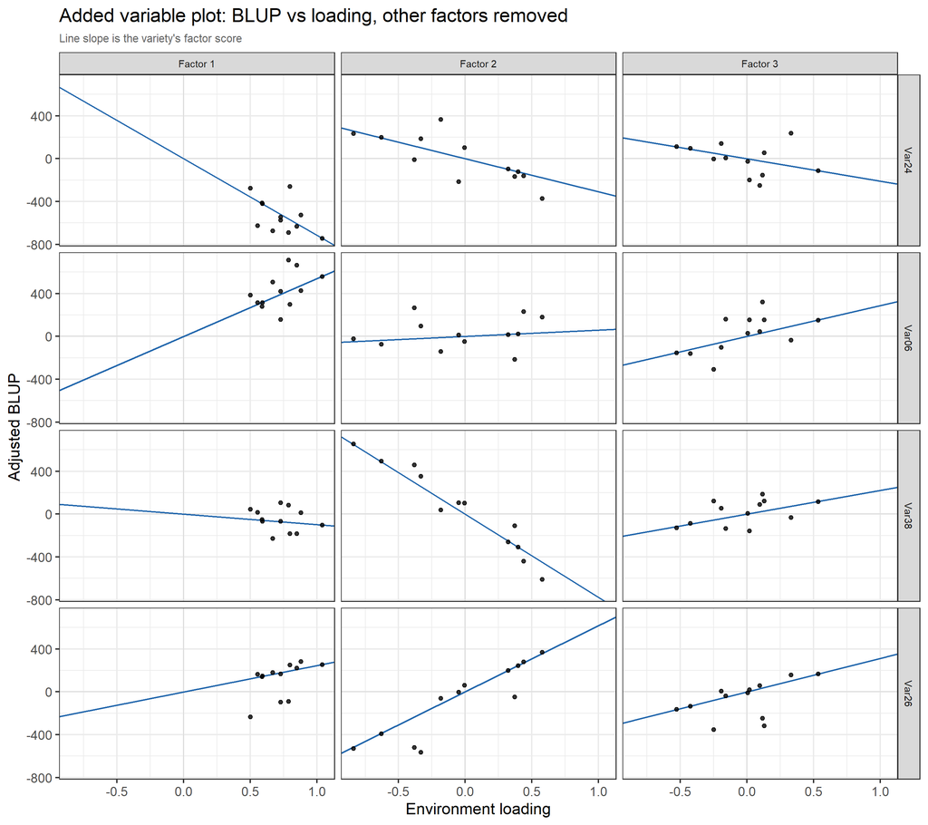

```r
plot_faSummary(fas1, type = "added", n_varieties = 4L)
```

### Returning the plotted data

Every type accepts `return_data = TRUE`, giving a list with `$plot` and `$data` instead of the plot alone — useful for tabulating or re-plotting.

```r
out <- plot_faSummary(fas1, type = "VAF", return_data = TRUE)
names(out$data)
```

```
[1] "env"     "summary"
```

```r
head(out$data$env, 3)
```

```
   Site   Factor1    Factor2    Factor3  Specific total_var
1 Env01 0.5476452 0.02912071 0.09520623 0.3280279  1.155181
2 Env02 0.2134918 0.09561358 0.01432246 0.6765721  1.170593
3 Env03 0.7099756 0.10274091 0.18728350 0.0000000  1.521005
```

## Combined `vm()` and `ide()` terms

A common MET model separates additive and non-additive genetic effects:

```r
random = ~ fa(Site, 2):vm(Variety, Ginv) + fa(Site, 2):ide(Variety)
```

Each term is summarised in its own right. In addition, when `combine.ide = TRUE` (the default) and such a pair shares the same outer and inner variables, `faSummary()` appends an extra entry named `"<outer>:<inner>-total"` holding the **summed** covariance matrix and summed BLUPs — the total genetic structure.

That entry has no loadings or scores of its own, because the sum of two FA structures is not itself an FA structure. Consequently only `type = "heatmap"` is available for it; the other four plot types raise an explanatory error. Pass `combine.ide = FALSE` to suppress it.

## Summary

### `faSummary()` arguments

| Argument | Default | Description |
| --- | --- | --- |
| `model` | — | Fitted ASReml-R V4 model whose random formula contains at least one `fa()` term |
| `term` | `NULL` | Character vector of FA term labels to summarise, e.g. `"fa(Site, 3):Variety"`. `NULL` summarises every FA term found |
| `blups` | `TRUE` | Return genotype BLUPs and factor score EBLUPs. `FALSE` skips the potentially expensive `coef()` call |
| `combine.ide` | `TRUE` | Append the summed `vm()` + `ide()` “total” structure where such a pair exists |

### `faSummary()` return

An object of class `faSummary` with `$gammas`, `$blups`, `$terms` and `$call`. Each `$gammas[[term]]` contains:

| Component | Description |
| --- | --- |
| `Gmat`, `Cmat` | $t \times t$ genetic covariance and correlation matrices |
| `loads` | $t \times k$ rotated loadings (columns `fac_1` … `fac_k`) |
| `loads_cor` | Correlation-scaled loadings; rows inside the unit hypersphere |
| `spec_var` | Specific variances, **unclamped** |
| `vaf_env` | Per-environment proportions: `Factor1` … `FactorK`, `Specific`, `total_var` |
| `vaf_summary` | Pooled proportions: `factor`, `pct_var`, `cum_pct` |
| `vaf_total` | Overall percentage accounted for by all $k$ factors |
| `k`, `env` | Number of factors; environment labels |
| `outer`, `inner`, `inner_fun` | Environment variable, genotype variable, and the wrapper on it (`id`, `vm`, `ide` or `total`) |

Each `$blups[[term]]` contains a `blups` data frame (`<outer>`, `<inner>`, `blup`, `regblup`, `pres`) and a `scores` data frame (`<outer>` holding `Comp1` … `Compk`, `<inner>`, `blup`, `blupr`).

> `pres` counts non-missing observations per environment × genotype and is `NA`, not `0`, where the combination is entirely absent.

### `plot_faSummary()` arguments

| Argument | Default | Description |
| --- | --- | --- |
| `res` | — | An object of class `faSummary` |
| `type` | `"VAF"` | One of `"VAF"`, `"heatmap"`, `"loadings"`, `"regress"`, `"added"` |
| `term` | `NULL` | Which FA term to plot; `NULL` takes the first carrying loadings |
| `order` | `"loading"` | Environment ordering for `"VAF"` and `"heatmap"`: `"loading"`, `"asis"` or `"cluster"` |
| `varieties` | `"default"` | Varieties for `"regress"` / `"added"`; `"default"` picks each factor’s extremes |
| `n_varieties` | `6L` | Maximum number selected by `"default"` |
| `tol` | `0.85` | Radius threshold flagging well-explained environments in `"loadings"` |
| `theme` | `theme_bw()` | A ggplot2 theme object |
| `return_data` | `FALSE` | `TRUE` returns `list($plot, $data)` |

### `plot_faSummary()` types

| Type | Requires | Description |
| --- | --- | --- |
| `"VAF"` | — | Stacked 100% bar chart per environment: one segment per factor plus specific variance, with a dashed overall-mean line |
| `"heatmap"` | — | Genetic correlation on a diverging palette centred at zero; the only type available for a combined `vm()` + `ide()` entry |
| `"loadings"` | $k \ge 2$ | Correlation-scaled loadings as vectors, one panel per factor pair, with the unit circle; `tol` splits solid from dotted |
| `"regress"` | `blups = TRUE` | BLUPs against loadings, faceted variety × factor; slope is the factor score |
| `"added"` | `blups = TRUE` | As `"regress"` with the other factors projected out — the correct display when $k \ge 2$ |

## References

Smith, A.B., Cullis, B.R. & Thompson, R. (2001). Analyzing variety by environment data using multiplicative mixed models and adjustments for spatial field trend. *Biometrics*, **57**, 1138–1147.

Smith, A.B. & Cullis, B.R. (2018). Plant breeding selection tools built on factor analytic mixed models for multi-environment trial data. *Euphytica*, **214**, 143.

Thompson, R., Cullis, B.R., Smith, A.B. & Gilmour, A.R. (2003). A sparse implementation of the average information algorithm for factor analytic and reduced rank variance models. *Australian & New Zealand Journal of Statistics*, **45**, 445–459.